# Presentacion-agudezia slides

[figure not shown]

Yuri Numerov (@Achifaifa)  
Diego Alonso (@DiegoAlGz)

Agudezia 2016 (2016-06-14)

### Makers de Gasteiz

[figure not shown]

### Historia

- Fundado por Patxi y Joseba
- Surgido de Bilbao Makers
- >2 años de recorrido

[figure not shown]

### Propósito

> Promover el conocimiento compartido, la imaginación y la creatividad para lograr una sociedad y un lugar mejor para vivir

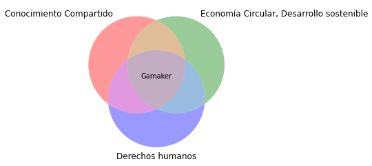

```python
%matplotlib inline
import pylab as plt
from matplotlib_venn import venn3, venn3_circles

v = venn3(subsets=(1, 1, 1, 1, 1, 1, 1), set_labels=labels)
notext(v)
plt.show()
```

### Nuestro ADN

[figure not shown]

#### Necesidades

- Aprender cosas nuevas
- Desarrollo de ideas innovadoras
- *Networking* tecnológico
- Reparar, aprender a reparar
- Mejora didáctica usando tecnología
- Educación tecnológica
- Reducción de resíduos tecnológicos
- Prácticas y proyectos académicos
- Imagen y prestigio para vitoria

#### Segmentos

- Monitores de tiempo libre (Necesidades tecnológicas)
- Pymes y usuarios profesionales
- Otras asociaciones
- Entidades de reciclaje
- Empresas de formación
- Inventores/Creadores
- Makers internacionales
- Universidades / Centros FP
- Ayuntamiento
- Emprendedores

#### Tecnologías

- **Conocimientos** de los socios
- Instalaciones preparadas: Equipos, herramientas, materiales...
- Red de makers y comunidades open source
- Capacidad de movilización y asistencia a eventos
  - Gasteiz Maker Day (Vitoria)
  - TEDxAlmMed (Vitoria)
  - Scratch day (Vitoria)
  - Arduino day (Zaragoza)
  - Araba / Gipuzkoa / Euskal encounter (Vitoria, Tolosa, Bilbao)
  - BIEMH (Bilbao)
  - PyConEs (Zaragoza, Valencia)
  - Fosdem (Bruselas)

### Gasteiz Maker Day

- Alrededor de 1000 personas
- 13 expositores
- 18 charlas y talleres

[figure not shown]

### Análisis del fenotipo

[figure not shown]

[Source](http://journal.frontiersin.org/article/10.3389/fpls.2013.00389/full) *Overexpression of chloroplast NADPH-dependent thioredoxin reductase in Arabidopsis enhances leaf growth and elucidates in vivo function of reductase and thioredoxin domains*, Jouni Toivola et al.

#### 7 propuestas de valor

##### Día de puertas abiertas

Para un perfil general (Curiosos)

Objetivo: Conocer la asociación

##### Actividades de ocio alternativo

Para un público joven

Objetivo: Disfrutar (Gauekoak, etc)

##### Café repair

Para no socios

Objetivo: Cubrir la necesidad de aprender (autosuficiencia)

##### Proyectos mentorizados de innovación

Para socios, socios+alianzas

Objetivo: Cerrar ciclos académicos, crear, innovar, emprender

##### Talleres de formación, *coding dojos*, cursos de verano

Para socios o no socios con curiosidad técnica

Objetivo: Aprender y adquirir habilidades nuevas

##### Reuniones informales

Para socios

Objetivo: Socialización y cacharreo

##### Eventos puntuales

Proyectos puntuales (Difusión) Estrategias internacionales (Canalización)

### Organización

#### Funciones y organización básica

- Gestión de relaciones con socios
- Gestión de redes sociales
- Relaciones con el exterior
- Coordinación de proyectos
- Administración contable

#### Gestión por proyectos

- Compromiso con el calendario de actividades
- Responsable de proyecto, mentorización
- Gestión de recursos

#### Herramientas de gestión

- "Identificación de Competencias y Coordinación de Capacidades" (Demo)
- Wiki, Foro, email/listas...

### Análisis del ecosistema

#### 6 factores del entorno político, social, económico y tecnológico

- Apoyo instituciones locales a la innovación y la tecnología
- Participación ciudadana, cultura local verde
- Legislación (prevención de riesgos, licencias, etc)
- Crisis/Estado económico. Mayor tendencia a la raparación y reutilización
- Conciencia social: la economía circular *`está de moda`*
- Asociacionismo a nivel global

#### 6 clientes y grupos de interés

- Clientes internos. Socios.
- Departamentos tecnológicos de organismos públicos
- Asociaciones de discapacitados
- Enseñanza. EUI de la UPV, Egibide
- Ayuntamiento de Vitoria
- Empresas. SPC, Doplay

#### Alternativas

##### Socialización:

- Otras asociaciones

##### Formación:

- Cursos especializados
- Autoformación
- Academias privadas

##### Creación de soluciones:

- Ingenierías
- Consultoras

##### Proyectos para estudiantes:

- PFC Universidad
- Prácticas en empresas

##### Reutilización / Reciclaje:

- Garbigune
- Servicios técnicos
- Tirar y comprar nuevo

#### Proveedores

- Ayuntamiento (Local)
- Ciudadanía [Donaciones (Material, económicas)]
- Socios (Cuotas, Conocimientos, tiempo)
- Empresas (Colaboraciones)
- Entidades públicas
- Otras asociaciones

### Espiral colaborativa

##### Bilbao Makers, DLabs

- Beneficio social
- Solidez
- Mayor capacidad tecnológica
- Oferta más amplia

##### Ayuntamiento de Vitoria

- Instalaciones
- Mayor capacidad de difusión
- Proyectos y eventos más ambiciosos

##### UPV

- Mayor valor académico, proyectos más prácticos e innovadores
- Plataforma para el emprendizaje con Agudezia
- Capacidad de difusión

##### Egibide

- Prescripción a un colectivo con capacidad profesional técnica

##### SPC

- Acceso a materiales novedosos
- participación en procesos de feedback técnico para makeblock
- oportunidades de inserción laboral

### Posición competitiva

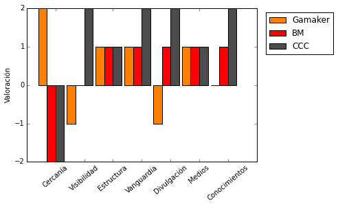

```python
fig, ax = plt.subplots()
rects1,rects2,rects3 = ax.bar(0.4+ind, gamakerscores, width, color=(1,0.5,0)),ax.bar(0.4+ind+width, bmscores, width, color='r'),ax.bar(0.4+ind+2*width, cccscores, width, color=(0.3,0.3,0.3))
ax.set_ylabel(u'Valoración'); ax.set_xticklabels([""]+[i["area"].decode("UTF-8") for i in data]); plt.xticks(rotation=40); plt.yticks([-2,-1,0,1,2]); ax.legend((rects1[0], rects2[0], rects3[0]), ('Gamaker', 'BM', 'CCC'), loc=1, bbox_to_anchor=(1.35, 1))
plt.show()
```

### Modelo estratégico

### Plan de desarrollo

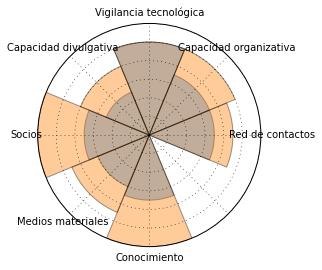

```python
ax = plt.subplot(111, projection='polar')
ax.set_xticklabels([i["FACTORES"].decode("UTF-8") for i in data][::-1]); ax.set_yticklabels([""])
presentbars=ax.bar(positions, presscores, width=np.pi/4, bottom=0.0)
pastbars=ax.bar(positions, pastscores, width=np.pi/4, bottom=0.0)
for bar in pastbars: bar.set_facecolor((1,0.5,0)); bar.set_alpha(0.4)
for bar in presentbars: bar.set_facecolor((0,0.5,1)); bar.set_alpha(0.4)

plt.show()
```

#### Objetivos estratégicos e indicadores

> n. Objetivo estratégico  
> Indicador: [Indicador] ([Previsiones (1,2,3 años)])

##### Desarrollar Gamaker como comunidad de conocimiento

```
1. Crecimiento en socios
Indicador: Nº socios (10-35-50)
```

```
2. Dedicación por socio
Indicador: Horas/mes (20-15-10)
```

```
3. Capacidad de formación en todas las áreas
Indicador: Horas/Área/Mes (5-7-10)
```

##### Dinamismo en la organización de actividades

```
1. Ejecución de actividades planificadas
Indicador: Actividades finalizadas con éxito (90%-95%-98%)
```

```
2. Satisfacción de los asistentes
Indicador: Resultados en encuestas (7-8-8.5)
```

##### Proyectos e innovación

```
1. Proyectos con UPV (Mentoring técnico)
Indicador: Proyectos anuales (0-2-4)
Indicador: Iniciativas empresariales (0-1-2)
```

```
2. Crear y dinamizar el Café Repair
Indicador: Sesiones anuales (4-6-10)
```

```
3. Colaboraciones con empresas
Indicador: Proyectos anuales (1-2-3)
```

##### Organización (Ligera y funcional)

```
1. Evaluación mensual de tareas, proyectos, etc
Indicador: Evaluaciones anuales (12-12-12)
```

```
2. Control de la funanciación
Indicador: Cobro puntual de las cuotas (95%-98%-98%)
```

```
3. Inventario y stock de recursos
Indicador: Inventarios anuales (1-1-1)
```

### Equilibrio metabólico

[figure not shown]

#### Herramienta

(Demo)

### Conclusiones

### ¡Gracias!

[figure not shown]

Yuri Numerov (@Achifaifa)  
Diego Alonso (@DiegoAlGz)

Agudezia 2016 (2016-06-14)

[gamaker3D@gmail.com](http://a.a) - [@Gamaker_](https://twitter.com/gamaker_)